# INFO 201 Assignment 3

Minsuh Kim

2/20/2022

###### **Introduction**

Throughout history, the United States has a history of injustice and inequality, especially in the topic of racism. The structures of over-policing and the “war on drugs” have led to the discriminated arrests of people in color. This assignment aims to reveal and analysis the bias and inequality within prison incarcerations. In the assignment, I have chosen to analyze the jail and prison population count, years, and states to calculate the amount of jailed people of different races throughout the years and how they might differ within different states. With these variables, I also decided to focus on the incarcerations of both White and Black races in my data visualizations.

###### **Summary Information**

Looking through the data, I found that the highest number of jailed black people ever recorded is **13,143.92** and the highest number of jailed white people ever recorded is **7036.59**. The data also shows that **California** has the highest total jailed population for both white and black people. While looking through the total jail admissions, the highest recorded number of admissions is **405,727** in 1988. While calculating the total jailed and imprisoned populations for the two races in different years, the results I received describe that there are a total of **247,547** black people and **346,061.8** white people in jail in 2018. For the population of imprisoned people, there are **405,266** blacks and **415,876** whites in prison in 2016.

###### **Trends Over Time Chart:**

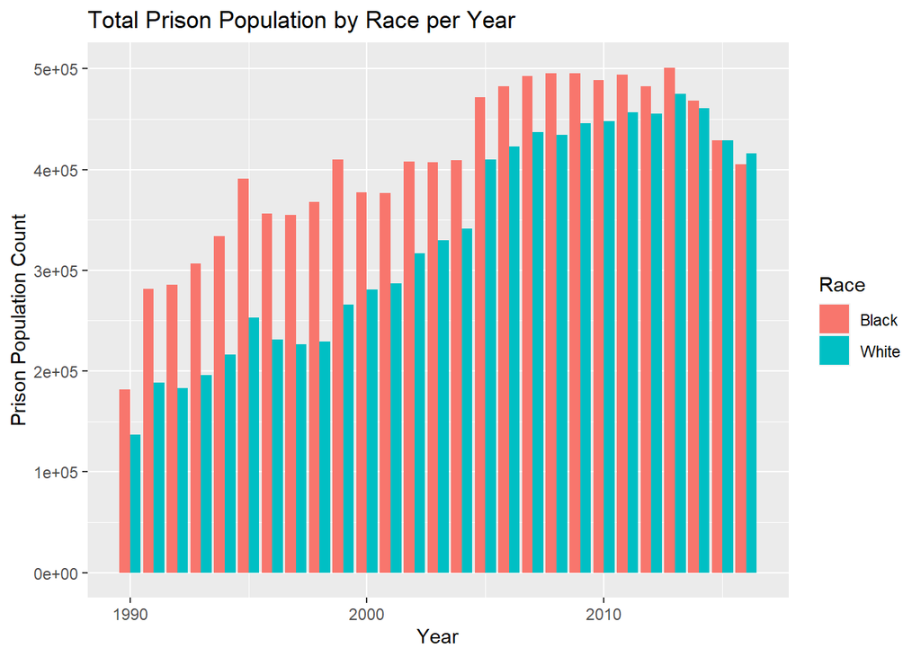

###### **Variable Comparison Chart:**

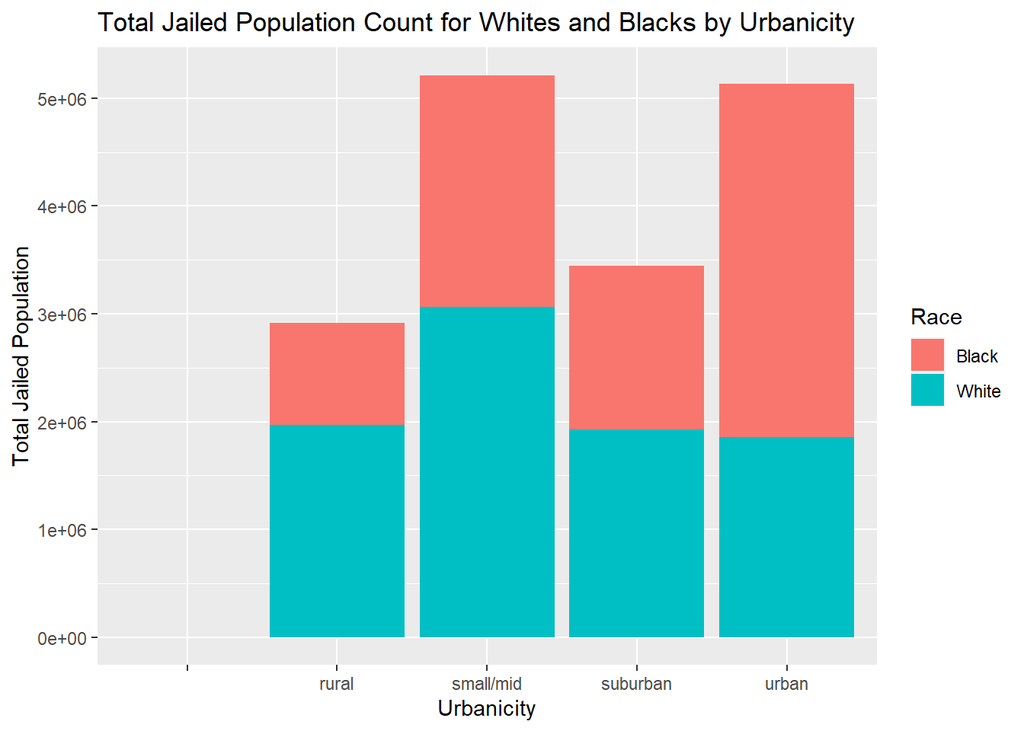

I decided to choose this chart because I wanted to look at how each race are impacted by the jail population. To do this, I created a stacked bar chart that compares the total jail population for whites and blacks through the geographic locations of urbanicity. From what I can find, this chart shows a pattern in which jailed black populations in urban areas are higher than jailed white populations while white populations in rural areas are higher than black populations.

###### **Map:**

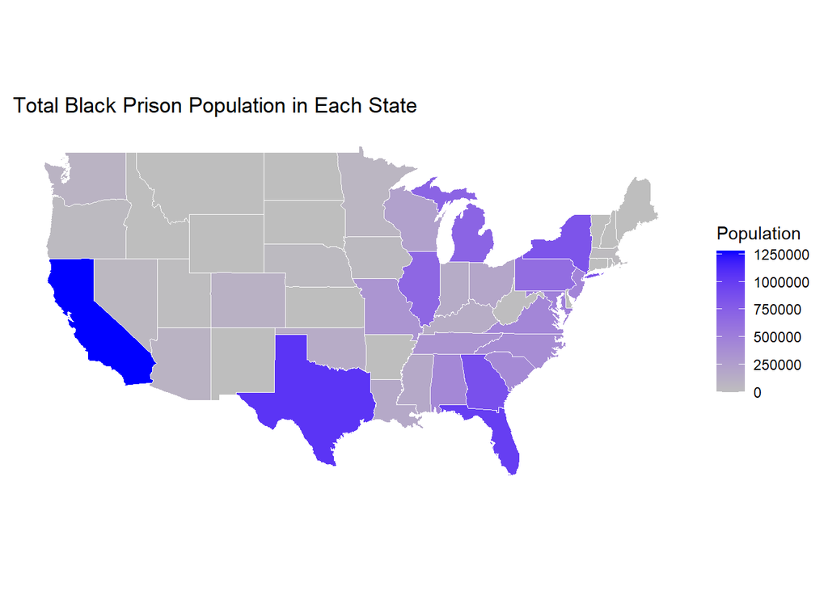